# Reproducible Research: Peer Assessment 1

## Loading and preprocessing the data

Start by loading the required packages and the data itself.

```r
library(dplyr)
library(ggplot2)
library(lubridate)
library(lattice)

dat <- read.csv("activity.csv", na.strings = "NA", stringsAsFactors = FALSE)
```

## What is mean total number of steps taken per day?

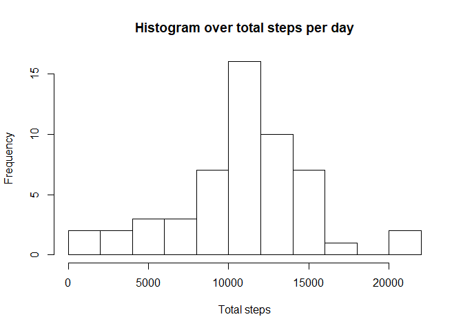

```r
totdat <- dat %>% group_by(date) %>% summarize(total_steps = sum(steps))

hist(totdat$total_steps, breaks = 15, xlab = "Total steps", main = "Histogram over total steps per day")
```

The mean and median are then calculated on the total steps per day column, using the option to remove NA entries.

```r
mean(totdat$total_steps, na.rm = TRUE)
```

```
## [1] 10766.19
```

```r
median(totdat$total_steps, na.rm = TRUE)
```

```
## [1] 10765
```

One can observe that the mean and median taken steps per day over the two months is around 10765. This indicates that the subject has healthy activity levels.

## What is the average daily activity pattern?

Calculate average steps per interval over all days and plot the results.

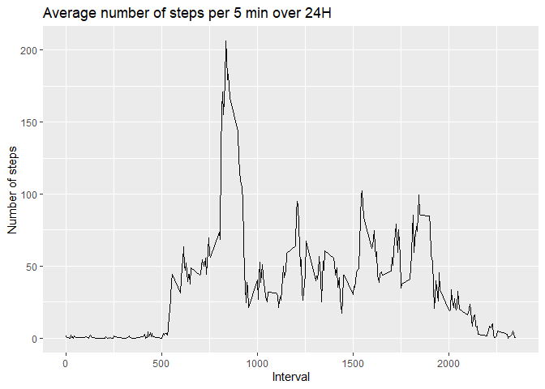

```r
dat %>%
        group_by(interval) %>%
        summarize(avg_steps = mean(steps, na.rm = TRUE)) %>%
        ggplot(aes(interval, avg_steps)) +
        geom_line() +
        labs(x = "Interval", y = "Number of steps", title = "Average number of steps per 5 min over 24H")
```

From these results we can deduct that the subject has a job which demands some moving about.

The 5 minute interval, which on average across all the days in the dataset, contains the maximum number of steps is calculated.

```r
avgdat <- dat %>% group_by(interval) %>% summarize(avg_steps = mean(steps, na.rm = TRUE))

avgdat$interval[which.max(avgdat$avg_steps)]
```

```
## [1] 835
```

From the reulting time series plot together with this result we see that the subject has an increased activity level around 08:35 o’clock over the span of the two months. This could correspond to a morning commute to work, or a routine to run in the morning for some days of the week.